# Predicting Wins with Pitching Statistics

Matt Goard

Last compiled: May 03, 2021

# 1 Introduction

As a high school student, I decided to enlist in the Navy. During that time, the thing that I missed the most was baseball. After being medically discharged from the Navy, one of the first things I did was find a baseball league to play in, and decided to give back and become a coach.

As I entered college, I could not imagine my life without baseball. I thought about becoming a teacher so that I could coach, but then the idea of becoming a sports analyst entered my mind. Since then I have worked with the varsity baseball team at Appalachian State as an analyst.

When presented with this project, I found it incredibly subjective with a lot of gray-area. I decided to fill this area by doing a project that will further my career with analyzing baseball statistics. Using the `Lahman` package, I was able to identify datasets that I could work with.

Many of my peers and data analysts tend to focus on batting statistics, as the Oakland Athletics focused on batting when they started the data revolution. The Athletics believed the way to win more baseball games is to score more runs, so they wondered how they could score more runs. Simply put, they found that on base percentage was the most important hitting statistic to scoring runs.

While scoring runs is very important to winning a baseball game, preventing runs from scoring can be considered equally important. This is done through both pitching and fielding. In looking at the available datasets in the `Lahman` package, I looked specifically at the datasets regarding pitching and fielding. I felt that the `Pitching` dataset would be better for model building as it was less information about positions and it was more raw statistics.

Through data manipulation and model building, this project will express how important pitching is, as well as how important specific statistics are, to winning baseball games.

# 2 Loading the Packages

In this section, I have loaded the `tidyverse`, `caret`, `broom`, and `Lahman` packages as I will need them to clean my data and create the models to predict wins in a given dataset.

```r
library(tidyverse)
library(caret)
library(broom)
library(Lahman)
```

# 3 Creating `WHIP`

A common statistic for pitchers is called `WHIP`. This is a measurement of how many walks and hits a pitcher allows for every inning pitched. Using the mutate function, I am able to create `WHIP` by adding `BB` and `H` together and dividing that by the `IPouts` divided by 3.

Should a pitcher allow fewer walks and hits, they should theoretically allow fewer runs. The lower a pitcher’s WHIP, the fewer runners are on base and can score, and the harder it is for a team to win.

```r
data(Pitching)
Pitching <- Pitching %>%
  filter(yearID > 1999) %>%
  group_by(teamID) %>%
  na.omit() %>%
  mutate(IP = IPouts/3,
         WHIP = (H + BB) / IP)
```

# 4 Splitting the Data

When creating models, it is important to randomize the data, and split the data into test sets and training sets to form more accurate models. This allows models to be “trained” around data so they are more accurate. It is then important to test these models with your `test` data to see if your model predicts other data as well.

```r
set.seed(500)
rows <- sample(nrow(Pitching))
Pitch <- Pitching[rows, ]
split <- round(nrow(Pitch)*0.70)
train <- Pitch[1:split, ]
test <- Pitch[(split + 1):nrow(Pitch), ]
```

# 5 Selection of Variables

In the dataset, there were some variables that were categorical. These variables included `playerID`, `yearID`, `teamID`, `lgID`, and `stint`. I chose to not use these variables because I wanted to predict wins just by a player’s statistics, not by any categorical data. This allows me to view how important each statistic is rather than how good each player is.

# 6 Creating a basic Linear Model

A classic prediction model is a basic linear model. A linear model is typically a good base model from which you can improve upon.

```r
(lm(W ~ . - playerID - yearID - teamID - lgID - stint, data = train))
```

```
Call:
lm(formula = W ~ . - playerID - yearID - teamID - lgID - stint,
    data = train)

Coefficients:
(Intercept)            L            G           GS           CG          SHO
  -0.356332    -0.247199     0.013778     0.098309     0.047003     0.354571
         SV       IPouts            H           ER           HR           BB
  -0.008034     0.013216    -0.015505    -0.003909    -0.013147    -0.009372
         SO        BAOpp          ERA          IBB           WP          HBP
   0.005340     0.266594     0.008219    -0.023240    -0.014686    -0.019034
         BK          BFP           GF            R           SH           SF
  -0.013980     0.011972    -0.005477    -0.028100    -0.005575    -0.038154
       GIDP           IP         WHIP
   0.019795           NA     0.003843
```

```r
myControl <- trainControl(
  method = "cv",
  number = 5)

lm_mod <- train(W ~ . - playerID - yearID - teamID - lgID - stint,
                data = train,
                trControl = myControl)
print(lm_mod)
```

```
Random Forest

10832 samples
   31 predictor

No pre-processing
Resampling: Cross-Validated (5 fold)
Summary of sample sizes: 8666, 8665, 8664, 8667, 8666
Resampling results across tuning parameters:

  mtry  RMSE      Rsquared   MAE
   2    1.478319  0.8727204  1.027375
  14    1.457720  0.8761473  1.019750
  26    1.455795  0.8765073  1.019040

RMSE was used to select the optimal model using the smallest value.
The final value used for the model was mtry = 26.
```

It can be seen by these coefficients that the more `SHO` a pitcher has, or the more shutouts they throw, the more likely a pitcher is to win. This makes sense as a shutout is defined as when a pitcher allows zero runs to score.

The model created through the `train` function has a `Rsquared` of approximately .875, meaning the variables selected account for approximately 87.5% of the variability of `W`.

# 7 Creating a Random Forest Model

Simply put, a random forest model creates multiple decision trees and merges them together to create a more accurate decision tree. I chose to create this model because it is a very logical model. The thought process behind decision trees is, “If this event is true, then the following outcome should happen.” This process also works in the opposite direction meaning a statement can be false and the decision tree predicts outcomes for this scenario.

I hypothesize this test to be the most accurate in predicting wins, noted in the dataset by `W`.

```r
rforest <- train(
  W ~ . - playerID - yearID - teamID - lgID - stint,
  tuneLength = 5,
  data = train,
  method = "ranger",
  trControl = myControl)

rforest$finalModel
```

```
Ranger result

Call:
 ranger::ranger(dependent.variable.name = ".outcome", data = x,      mtry = min(param$mtry, ncol(x)), min.node.size = param$min.node.size,      splitrule = as.character(param$splitrule), write.forest = TRUE,      probability = classProbs, ...)

Type:                             Regression
Number of trees:                  500
Sample size:                      10832
Number of independent variables:  26
Mtry:                             26
Target node size:                 5
Variable importance mode:         none
Splitrule:                        extratrees
Number of random splits:          1
OOB prediction error (MSE):       2.074126
R squared (OOB):                  0.8789018
```

This model created 500 decision trees and merged them together to predict how many wins a pitcher had based on all other variables. It was found that the other variables accounted for roughly 88% of wins. It is also seen that the MSE is approximately 2.08, meaning the RMSE is approximately 1.44. This means that this random forest model can predict how many pitches a pitcher will have $\pm$ 1.44 wins.

```r
p2 <- predict(rforest$finalModel, data = test)
e2 <- (test$W - p2$predictions)
RMSErf <- sqrt(mean(e2^2))
RMSErf
```

```
[1] 1.442594
```

In running the code chunk above, it can be seen that the actual value for the RMSE of the random forest model is 1.443. This is very close to the one calculated from the OOB data.

# 8 Creating a GLMnet model

A GLMnet model is a logistic regression model that accounts for redundant variables, which is when two predictor variables have a similar relation to the response variable. In building multiple regression models, it is important to not have redundant variables, making this an important model. For this reason I chose a GLMnet model.

```r
glmnetmod <- train(W ~ . - playerID - yearID - teamID - lgID - stint,
               data = train,
               method = "glmnet",
               trControl = myControl)
print(glmnetmod)
```

```
glmnet

10832 samples
   31 predictor

No pre-processing
Resampling: Cross-Validated (5 fold)
Summary of sample sizes: 8666, 8665, 8665, 8665, 8667
Resampling results across tuning parameters:

  alpha  lambda       RMSE      Rsquared   MAE
  0.10   0.007595263  1.467604  0.8742120  1.029968
  0.10   0.075952626  1.476637  0.8728231  1.035850
  0.10   0.759526263  1.606138  0.8518121  1.113728
  0.55   0.007595263  1.467631  0.8742297  1.029999
  0.55   0.075952626  1.506283  0.8679822  1.059054
  0.55   0.759526263  1.693143  0.8470106  1.172748
  1.00   0.007595263  1.468628  0.8740812  1.030926
  1.00   0.075952626  1.524418  0.8651016  1.068623
  1.00   0.759526263  1.793034  0.8467143  1.255955

RMSE was used to select the optimal model using the smallest value.
The final values used for the model were alpha = 0.1 and lambda = 0.007595263.
```

The `glmnetmod` found that the optimum model had an alpha of `.1` and a lambda of approximately `. 00759`. This is important because this model has the lowest variance in results, meaning that the model has the smallest error. The error, or RMSE, for this optimum model has a value of approximately `1.47`. This means the error is slightly more than the random forest model above, but I still believe this to be a good model. For a model to predict within $\pm$ `1.47` wins is still good.

# 9 Comparing the Models

To discover which model is truly the best model, it is important to compare all of them. In looking at the graphs for `Rsquared`, `RMSE`, and `MAE`, it can be seen that the largest `Rsquared` is for the random forest model, meaning that the variables used have the highest prediction level. This is followed by the linear model and then the elastic net model.

This order is seen in reverse for the `RMSE`, or the error. This means the random forest model has the least amount of error, followed by the linear model and then the elastic net model.

These graphs prove my hypothesis that the random forest model was best suited to predict wins.

```r
ANS <- resamples(list(RF = rforest, ENET = glmnetmod, LM = lm_mod))
round(summary(ANS)[[3]]$RMSE, 4)
```

```
       Min. 1st Qu. Median   Mean 3rd Qu.   Max. NA's
RF   1.3970  1.4417 1.4567 1.4442  1.4596 1.4659    0
ENET 1.4150  1.4454 1.4566 1.4676  1.5026 1.5184    0
LM   1.4341  1.4426 1.4556 1.4558  1.4623 1.4844    0
```

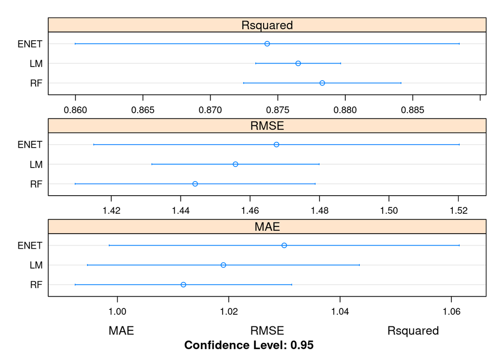

```r
dotplot(ANS, scales = "free", layout = c(1, 3))
```

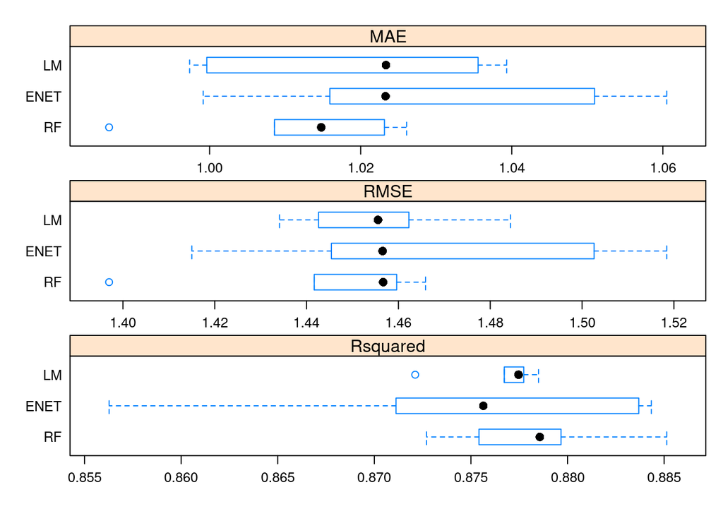

```r
bwplot(ANS, layout = c(1, 3), scales = "free", as.table = TRUE)
```